# Homework 4 and 5

### Without regressors

```python
from statsmodels.tsa.arima.model import ARIMA
model = ARIMA(random, order=(3,0,1))
model_fit = model.fit()
model_fit.summary()
```

SARIMAX Results

| Dep. Variable: | resid | No. Observations: | 383 |
| --- | --- | --- | --- |
| Model: | ARIMA(3, 0, 1) | Log Likelihood | -2537.602 |
| Date: | Wed, 30 Jun 2021 | AIC | 5087.204 |
| Time: | 14:37:37 | BIC | 5110.892 |
| Sample: | 0 | HQIC | 5096.601 |
|  | - 383 |  |  |
| Covariance Type: | opg |  |  |

|  | coef | std err | z | P>\|z\| | [0.025 | 0.975] |
| --- | --- | --- | --- | --- | --- | --- |
| const | 0.0302 | 0.237 | 0.127 | 0.899 | -0.434 | 0.495 |
| ar.L1 | 0.9245 | 0.044 | 21.235 | 0.000 | 0.839 | 1.010 |
| ar.L2 | -0.3766 | 0.062 | -6.066 | 0.000 | -0.498 | -0.255 |
| ar.L3 | -0.1002 | 0.038 | -2.621 | 0.009 | -0.175 | -0.025 |
| ma.L1 | -1.0000 | 0.031 | -32.113 | 0.000 | -1.061 | -0.939 |
| sigma2 | 4.048e+04 | 7.7e-07 | 5.26e+10 | 0.000 | 4.05e+04 | 4.05e+04 |

| Ljung-Box (L1) (Q): | 0.00 | Jarque-Bera (JB): | 15009.38 |
| --- | --- | --- | --- |
| Prob(Q): | 0.97 | Prob(JB): | 0.00 |
| Heteroskedasticity (H): | 1.60 | Skew: | 3.34 |
| Prob(H) (two-sided): | 0.01 | Kurtosis: | 32.93 |

Warnings:  
[1] Covariance matrix calculated using the outer product of gradients (complex-step).  
[2] Covariance matrix is singular or near-singular, with condition number 1.82e+26. Standard errors may be unstable.

### With external regressor

```python
from statsmodels.tsa.arima.model import ARIMA
model = ARIMA(random, order=(3,0,1), exog = regressors)
model_fit = model.fit()
model_fit.summary()
```

SARIMAX Results

| Dep. Variable: | resid | No. Observations: | 383 |
| --- | --- | --- | --- |
| Model: | ARIMA(3, 0, 1) | Log Likelihood | -2442.024 |
| Date: | Wed, 30 Jun 2021 | AIC | 4902.048 |
| Time: | 14:37:44 | BIC | 4937.580 |
| Sample: | 0 | HQIC | 4916.143 |
|  | - 383 |  |  |
| Covariance Type: | opg |  |  |

|  | coef | std err | z | P>\|z\| | [0.025 | 0.975] |
| --- | --- | --- | --- | --- | --- | --- |
| const | -150.9333 | 84.270 | -1.791 | 0.073 | -316.100 | 14.234 |
| basket_count | 0.2154 | 0.017 | 12.755 | 0.000 | 0.182 | 0.249 |
| Category Favored | -0.0313 | 0.004 | -8.836 | 0.000 | -0.038 | -0.024 |
| Category Sold | 0.2053 | 0.006 | 34.581 | 0.000 | 0.194 | 0.217 |
| ar.L1 | 0.2425 | 0.261 | 0.929 | 0.353 | -0.269 | 0.754 |
| ar.L2 | 0.6438 | 0.220 | 2.926 | 0.003 | 0.213 | 1.075 |
| ar.L3 | -0.1898 | 0.062 | -3.056 | 0.002 | -0.312 | -0.068 |
| ma.L1 | 0.7106 | 0.263 | 2.698 | 0.007 | 0.194 | 1.227 |
| sigma2 | 3.054e+04 | 1930.957 | 15.816 | 0.000 | 2.68e+04 | 3.43e+04 |

| Ljung-Box (L1) (Q): | 0.01 | Jarque-Bera (JB): | 1345.41 |
| --- | --- | --- | --- |
| Prob(Q): | 0.90 | Prob(JB): | 0.00 |
| Heteroskedasticity (H): | 0.89 | Skew: | -1.09 |
| Prob(H) (two-sided): | 0.51 | Kurtosis: | 11.92 |

Warnings:  
[1] Covariance matrix calculated using the outer product of gradients (complex-step).

### The model imroved but the first AR term has lost its significancy . However I am going to forecast with this model.

## Forecasting and model performance measures

```python
regressors = pd.DataFrame(pr8["basket_count"].head(7))
regressors["Category Favored"] = pr8["category_favored"].head(7)
regressors["Category Sold"] = pr8["category_sold"].head(7)
```

```python
forecast = model_fit.forecast(steps = 7, exog = regressors.head(7))
```

```python
trend = trend.fillna(np.mean(trend.dropna().head(10)))
trend_comp = trend.head(7).values
season_comp = list(season[371:378])
season_comp.reverse()
```

```python
forecast_normalized = forecast.values+ trend_comp+ season_comp
```

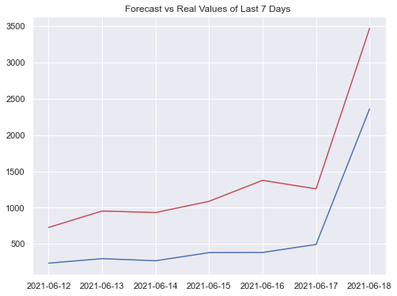

```python
plt.plot(test_data.index,forecast_normalized, c = "r")
plt.plot(test_data.index,test_data, c = "b")
plt.title("Forecast vs Real Values of Last 7 Days ")
plt.show()
```

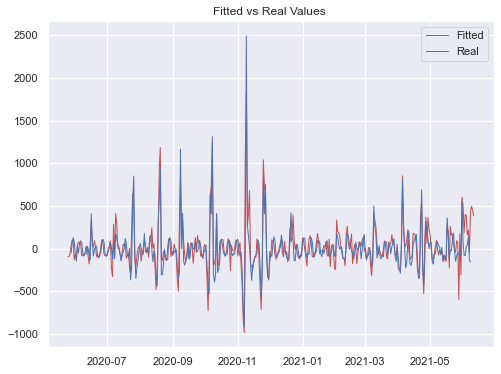

```python
new_df = pd.DataFrame(model_fit.fittedvalues,  index = model_fit.fittedvalues.index)
new_df.columns = ["Fitted"]
new_df["Real"] = random
plt.plot(train_data.index,new_df.Fitted, c = "r",linewidth=1, label = "Fitted")
plt.plot(train_data.index,new_df.Real, c = "b", linewidth=1, label = "Real")
plt.title("Fitted vs Real Values ")
plt.legend()
plt.show()
```

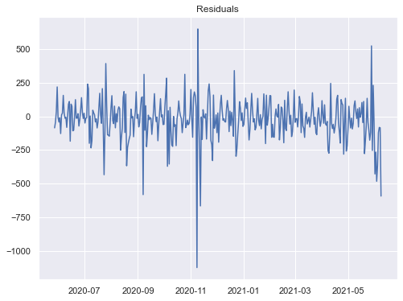

```python
plt.plot(model_fit.resid)
plt.title("Residuals")
plt.show()
```

## Conclusion

### Overall looking the model, zero mean and independency of the residuals assumptions seem to be held by looking at the residuals. For this product, I might use ARIMAX model rather than LM model. But the at some points, peaks should be excluded.

# Product 3

- For the product 3, I followed the same steps of product 1. Therefore, I am going to skip the descriptive comments and keep the related ones only.

## 1 ) Importing and Manipulating the data for the first three product

```python
pr9 = pd.read_csv("alldata_item9.csv")
```

```python
pr9["event_date"] = pd.to_datetime(pr9["event_date"], format = "%d/%m/%Y") # converting event date into datetime object
pr9['Month'] = pr9['event_date'].dt.month #adding month information as a numeric variable
pr9.drop('Unnamed: 0',axis='columns', inplace=True)
pr9['Day'] = pr9['event_date'].dt.weekday #adding day information as a numeric variable
pr9.set_index("event_date" , inplace = True) # setting index time series
pr9.head()
```

| event_date | price | product_content_id | sold_count | visit_count | favored_count | basket_count | category_sold | category_brand_sold | category_visits | ty_visits | category_basket | category_favored | w_day | Month | weeknumber | Day |
| --- | --- | --- | --- | --- | --- | --- | --- | --- | --- | --- | --- | --- | --- | --- | --- | --- |
| 2021-06-18 | 146.22 | 32939029 | 108 | 3400 | 369 | 366 | 638 | 604 | 28504 | 91784941 | 2368 | 3375 | Fri | 6 | 24 | 4 |
| 2021-06-17 | 151.76 | 32939029 | 135 | 3588 | 367 | 381 | 805 | 766 | 33290 | 102409626 | 2639 | 4393 | Thu | 6 | 24 | 3 |
| 2021-06-16 | 154.62 | 32939029 | 169 | 5338 | 616 | 631 | 977 | 924 | 34081 | 105918459 | 3425 | 3168 | Wed | 6 | 24 | 2 |
| 2021-06-15 | 140.50 | 32939029 | 265 | 5643 | 632 | 873 | 1016 | 983 | 33020 | 103541571 | 3421 | 3108 | Tue | 6 | 24 | 1 |
| 2021-06-14 | 140.86 | 32939029 | 245 | 5633 | 755 | 822 | 959 | 922 | 34965 | 107738598 | 3481 | 3900 | Mon | 6 | 24 | 0 |

```python
sold = pd.DataFrame(pr9.sold_count)
sold.head()
```

| event_date | sold_count |
| --- | --- |
| 2021-06-18 | 108 |
| 2021-06-17 | 135 |
| 2021-06-16 | 169 |
| 2021-06-15 | 265 |
| 2021-06-14 | 245 |

# 2 ) Visualizations

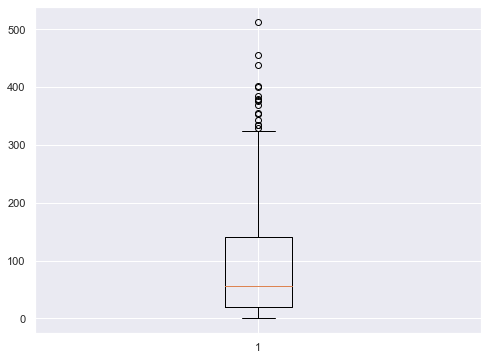

```python
plt.boxplot(sold);
```

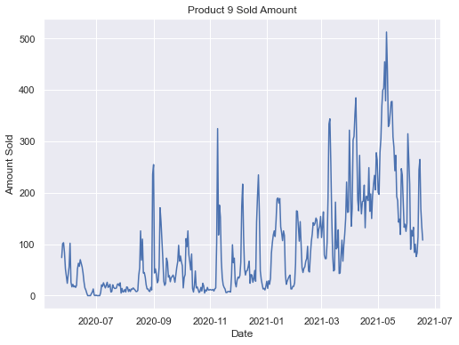

```python
sns.set(rc={'figure.figsize':(8,6)})
plt.title("Product 9 Sold Amount")
plt.xlabel("Date")
plt.ylabel("Amount Sold")
plt.plot(sold)
plt.show();
```

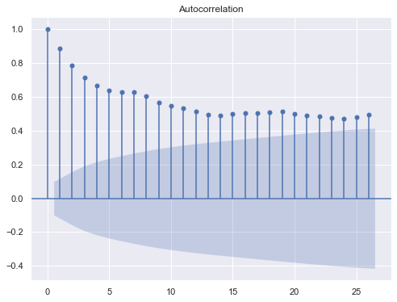

```python
from statsmodels.graphics.tsaplots import plot_acf
plot_acf(sold)
plt.show()
```

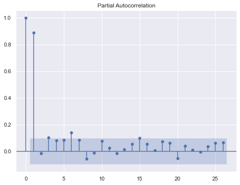

```python
from statsmodels.graphics.tsaplots import plot_pacf
plot_pacf(sold)
plt.show()
```

# 3 ) Decomposing the data

### Weekly Seasonality

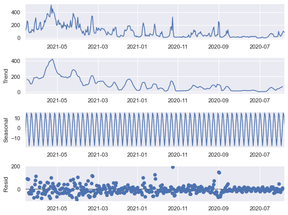

```python
from statsmodels.tsa.seasonal import seasonal_decompose
result = seasonal_decompose(sold, model='additive', period = 7 )
result.plot()
plt.show();
```

### Monthly Seasonality

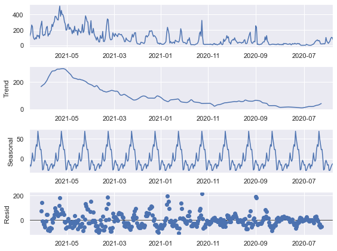

```python
result = seasonal_decompose(sold, model='additive', period = 30 )
result.plot()
plt.show();
```

[figure not shown]

```python
plt.title("Random Term of Weekly Decomposed Data")
result.resid.plot()
plt.show();
```

### Random term after decomposing monthly

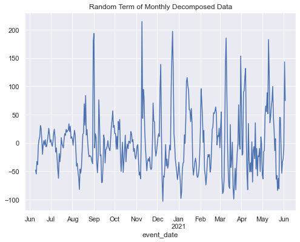

```python
plt.title("Random Term of Monthly Decomposed Data")
result.resid.plot()
plt.show();
```

## Conclusion

```python
random = result.resid
trend = result.trend
season = result.seasonal
```

# Task 2- Fitting data into ARIMA Model

## 1 ) Deciding on the parameters

- To decide on the parameters of the ARIMA model, I checked the ACF and PACF plots of the data. ACF plot has sinusodial pattern and PACF function has a negative correlation after lag 1.I am going to check the neighborhood to find the best model.

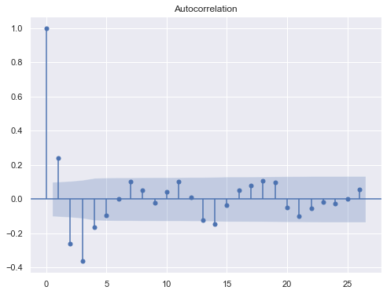

```python
plot_acf(random.dropna())
plt.show();
```

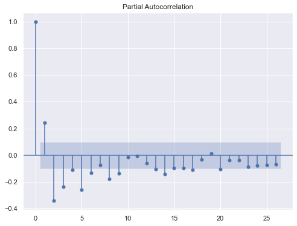

```python
plot_pacf(random.dropna())
plt.show();
```

```python
from statsmodels.tsa.arima.model import ARIMA
model = ARIMA(random, order=(1,0,0))
model_fit = model.fit()
model_fit.aic
```

```
3826.3690814983665
```

```python
from statsmodels.tsa.arima.model import ARIMA
model = ARIMA(random, order=(2,0,0))
model_fit = model.fit()
model_fit.aic
```

```
3780.46672065237
```

```python
from statsmodels.tsa.arima.model import ARIMA
model = ARIMA(random, order=(3,0,0))
model_fit = model.fit()
model_fit.aic
```

```
3758.944026875475
```

```python
from statsmodels.tsa.arima.model import ARIMA
model = ARIMA(random, order=(3,0,1))
model_fit = model.fit()
model_fit.aic
```

```
3671.865267505148
```

```python
from statsmodels.tsa.arima.model import ARIMA
model = ARIMA(random, order=(3,0,2))
model_fit = model.fit()
model_fit.aic
```

```
3673.082194470614
```

```python
from statsmodels.tsa.arima.model import ARIMA
model = ARIMA(random, order=(4,0,1))
model_fit = model.fit()
model_fit.aic
```

```
3673.5962686998478
```

```python
from statsmodels.tsa.arima.model import ARIMA
model = ARIMA(random, order=(2,0,2))
model_fit = model.fit()
model_fit.aic
```

```
3671.8228042291266
```

```python
from statsmodels.tsa.arima.model import ARIMA
model = ARIMA(random, order=(1,0,3))
model_fit = model.fit()
model_fit.aic
```

```
3680.4414408404236
```

```python
from statsmodels.tsa.arima.model import ARIMA
model = ARIMA(random, order=(1,0,2))
model_fit = model.fit()
model_fit.aic
```

```
3707.898627507774
```

```python
from statsmodels.tsa.arima.model import ARIMA
model = ARIMA(random, order=(0,0,1))
model_fit = model.fit()
model_fit.aic
```

```
3810.9285151002987
```

```python
from statsmodels.tsa.arima.model import ARIMA
model = ARIMA(random, order=(0,0,2))
model_fit = model.fit()
model_fit.aic
```

```
3757.856285134436
```

```python
from statsmodels.tsa.arima.model import ARIMA
model = ARIMA(random, order=(4,0,2))
model_fit = model.fit()
model_fit.aic
```

```
3675.5933800304438
```

```python
from statsmodels.tsa.arima.model import ARIMA
model = ARIMA(random, order=(2,0,1))
model_fit = model.fit()
model_fit.aic
```

```
3669.8701675230554
```

```python
from statsmodels.tsa.arima.model import ARIMA
model = ARIMA(random, order=(2,0,1))
model_fit = model.fit()
model_fit.summary()
```

SARIMAX Results

| Dep. Variable: | resid | No. Observations: | 390 |
| --- | --- | --- | --- |
| Model: | ARIMA(2, 0, 1) | Log Likelihood | -1829.935 |
| Date: | Wed, 30 Jun 2021 | AIC | 3669.870 |
| Time: | 15:05:33 | BIC | 3689.701 |
| Sample: | 0 | HQIC | 3677.731 |
|  | - 390 |  |  |
| Covariance Type: | opg |  |  |

|  | coef | std err | z | P>\|z\| | [0.025 | 0.975] |
| --- | --- | --- | --- | --- | --- | --- |
| const | -0.0016 | 0.036 | -0.045 | 0.964 | -0.072 | 0.069 |
| ar.L1 | 0.9769 | 0.033 | 29.586 | 0.000 | 0.912 | 1.042 |
| ar.L2 | -0.5113 | 0.033 | -15.387 | 0.000 | -0.576 | -0.446 |
| ma.L1 | -1.0000 | 5.162 | -0.194 | 0.846 | -11.118 | 9.118 |
| sigma2 | 794.6173 | 4102.649 | 0.194 | 0.846 | -7246.427 | 8835.662 |

| Ljung-Box (L1) (Q): | 0.02 | Jarque-Bera (JB): | 391.78 |
| --- | --- | --- | --- |
| Prob(Q): | 0.89 | Prob(JB): | 0.00 |
| Heteroskedasticity (H): | 0.33 | Skew: | 0.81 |
| Prob(H) (two-sided): | 0.00 | Kurtosis: | 7.64 |

Warnings:  
[1] Covariance matrix calculated using the outer product of gradients (complex-step).

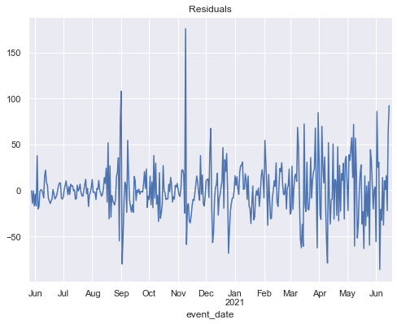

```python
plt.title("Residuals")
model_fit.resid.plot();
plt.show()
```

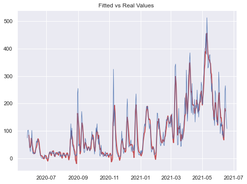

```python
new_df = pd.DataFrame(model_fit.fittedvalues + trend+season,  index = model_fit.fittedvalues.index)
new_df.columns = ["Fitted"]
new_df["Real"] = sold
plt.plot(random.index,new_df.Fitted, c = "r",linewidth=2)
plt.plot(random.index,new_df.Real, c = "b", linewidth=0.8,)
plt.title("Fitted vs Real Values ")
plt.show()
```

# Task 3 and 4 - Adding external regressors to the model

- In this part, I am going to look for variables that might be correlated to sold amount and can be used as regressors in the ARIMAX model. To do this, first I am going to use pairplots. But some of the data in the columns are lost for so many data points. So only columns I can use for this, "Basket Count" , "Category Sold" , Category Visits" and "Category Favored". I checked the relation of each variable with the sold count. From the visualizations, Basket Count seems to have a correlation, so I am going to add that variable to the model.

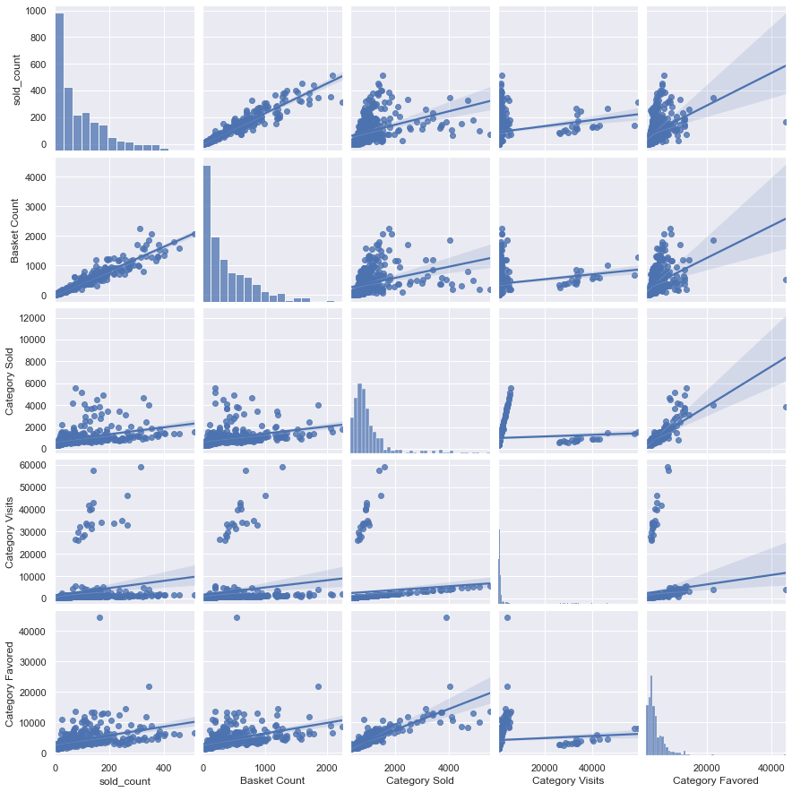

```python
pairplot = pd.DataFrame(pr9["sold_count"])
pairplot["Basket Count"] = pr9["basket_count"]
pairplot["Category Sold"] = pr9["category_sold"]
pairplot["Category Visits"] = pr9["category_visits"]
pairplot["Category Favored"] = pr9["category_favored"]
sns.pairplot(pairplot, kind = "reg");
```

## 2 ) Adding regressors to the ARIMA model

```python
train_data = sold.drop(sold.head(7).index)
train_data.head()
```

| event_date | sold_count |
| --- | --- |
| 2021-06-11 | 76 |
| 2021-06-10 | 100 |
| 2021-06-09 | 84 |
| 2021-06-08 | 133 |
| 2021-06-07 | 116 |

```python
test_data = sold.head(7)
test_data.head()
```

| event_date | sold_count |
| --- | --- |
| 2021-06-18 | 108 |
| 2021-06-17 | 135 |
| 2021-06-16 | 169 |
| 2021-06-15 | 265 |
| 2021-06-14 | 245 |

```python
regressors = pd.DataFrame(pr9["basket_count"].drop(pr9.head(7).index))


regressors.head()
```

| event_date | basket_count |
| --- | --- |
| 2021-06-11 | 267 |
| 2021-06-10 | 384 |
| 2021-06-09 | 406 |
| 2021-06-08 | 523 |
| 2021-06-07 | 494 |

### Now I need to decompose my train data and fit the model with and without external regressors.

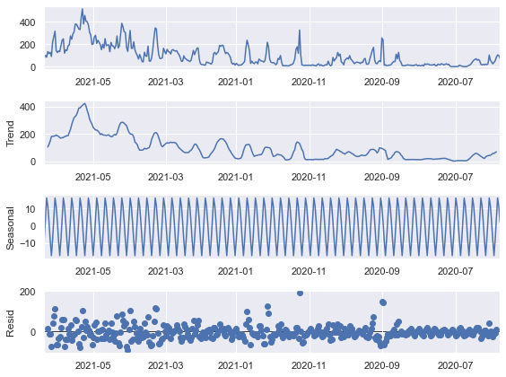

```python
from statsmodels.tsa.seasonal import seasonal_decompose
result = seasonal_decompose(train_data, model='additive', period = 7 )
trend = result.trend
season = result.seasonal
random = result.resid
result.plot();
```

### Without regressors

```python
from statsmodels.tsa.arima.model import ARIMA
model = ARIMA(random, order=(2,0,1))
model_fit = model.fit()
model_fit.summary()
```

SARIMAX Results

| Dep. Variable: | resid | No. Observations: | 383 |
| --- | --- | --- | --- |
| Model: | ARIMA(2, 0, 1) | Log Likelihood | -1794.036 |
| Date: | Wed, 30 Jun 2021 | AIC | 3598.072 |
| Time: | 15:34:18 | BIC | 3617.812 |
| Sample: | 0 | HQIC | 3605.903 |
|  | - 383 |  |  |
| Covariance Type: | opg |  |  |

|  | coef | std err | z | P>\|z\| | [0.025 | 0.975] |
| --- | --- | --- | --- | --- | --- | --- |
| const | 0.0024 | 0.037 | 0.064 | 0.949 | -0.071 | 0.076 |
| ar.L1 | 0.9698 | 0.032 | 30.092 | 0.000 | 0.907 | 1.033 |
| ar.L2 | -0.4989 | 0.034 | -14.813 | 0.000 | -0.565 | -0.433 |
| ma.L1 | -1.0000 | 5.892 | -0.170 | 0.865 | -12.549 | 10.549 |
| sigma2 | 783.8708 | 4618.048 | 0.170 | 0.865 | -8267.337 | 9835.079 |

| Ljung-Box (L1) (Q): | 0.00 | Jarque-Bera (JB): | 435.38 |
| --- | --- | --- | --- |
| Prob(Q): | 0.95 | Prob(JB): | 0.00 |
| Heteroskedasticity (H): | 0.35 | Skew: | 0.93 |
| Prob(H) (two-sided): | 0.00 | Kurtosis: | 7.88 |

Warnings:  
[1] Covariance matrix calculated using the outer product of gradients (complex-step).

### With external regressor

```python
from statsmodels.tsa.arima.model import ARIMA
model = ARIMA(random, order=(2,0,1), exog = regressors)
model_fit = model.fit()
model_fit.summary()
```

SARIMAX Results

| Dep. Variable: | resid | No. Observations: | 383 |
| --- | --- | --- | --- |
| Model: | ARIMA(2, 0, 1) | Log Likelihood | -1797.091 |
| Date: | Wed, 30 Jun 2021 | AIC | 3606.182 |
| Time: | 15:16:47 | BIC | 3629.870 |
| Sample: | 0 | HQIC | 3615.579 |
|  | - 383 |  |  |
| Covariance Type: | opg |  |  |

|  | coef | std err | z | P>\|z\| | [0.025 | 0.975] |
| --- | --- | --- | --- | --- | --- | --- |
| const | -0.1058 | 0.200 | -0.528 | 0.597 | -0.498 | 0.287 |
| basket_count | 0.0003 | 0.000 | 1.113 | 0.266 | -0.000 | 0.001 |
| ar.L1 | 0.9694 | 0.038 | 25.551 | 0.000 | 0.895 | 1.044 |
| ar.L2 | -0.5136 | 0.040 | -12.735 | 0.000 | -0.593 | -0.435 |
| ma.L1 | -0.9803 | 0.033 | -29.999 | 0.000 | -1.044 | -0.916 |
| sigma2 | 942.4733 | 59.863 | 15.744 | 0.000 | 825.144 | 1059.802 |

| Ljung-Box (L1) (Q): | 0.04 | Jarque-Bera (JB): | 463.90 |
| --- | --- | --- | --- |
| Prob(Q): | 0.84 | Prob(JB): | 0.00 |
| Heteroskedasticity (H): | 0.35 | Skew: | 0.87 |
| Prob(H) (two-sided): | 0.00 | Kurtosis: | 8.10 |

Warnings:  
[1] Covariance matrix calculated using the outer product of gradients (complex-step).

## Forecasting and model performance measures

```python
forecast = model_fit.forecast(steps = 7)
```

```python
trend = trend.fillna(np.mean(trend.dropna().head(10)))
trend_comp = trend.head(7).values
season_comp = list(season[371:378])
season_comp.reverse()
```

```python
forecast_normalized = forecast.values+ trend_comp+ season_comp
```

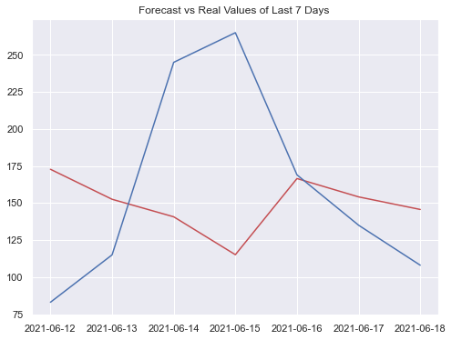

```python
plt.plot(test_data.index,forecast_normalized, c = "r")
plt.plot(test_data.index,test_data, c = "b")
plt.title("Forecast vs Real Values of Last 7 Days ")
plt.show()
```

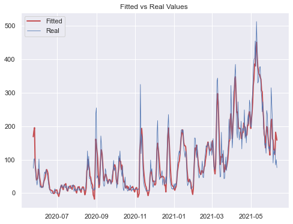

```python
new_df = pd.DataFrame(model_fit.fittedvalues + trend+season,  index = model_fit.fittedvalues.index)
new_df.columns = ["Fitted"]
new_df["Real"] = sold
plt.plot(train_data.index,new_df.Fitted, c = "r",linewidth=2, label = "Fitted")
plt.plot(train_data.index,new_df.Real, c = "b", linewidth=0.8, label = "Real")
plt.title("Fitted vs Real Values ")
plt.legend()
plt.show()
```

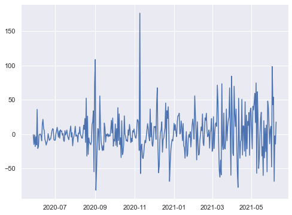

```python
plt.plot(model_fit.resid)
plt.show();
```